# PR1

Mineria de dades

Autor: Jordi Gironés Roig  
Coordinació: Julià Minguillón Alfonso

## Índex de continguts

1. Plantejament
2. Joc de dades
3. Llibreries de Python
4. Verificació de les dades
5. Anàlisis Exploratòria
6. SVD
7. Conclusions

## Plantejament

[ inici del document ]

Al llarg del curs hem vist que la mineria de dades és una eina crucial per a la comprensió i l'anàlisi de grans volums de dades. En aquesta pràctica aplicarem els conceptes vistos a les pràctiques al material didàctic. Per fer-ho, treballarem amb l'Adult UCI Dataset (https://archive.ics.uci.edu/dataset/2/adult), un joc de dades que inclou informació sobre atributs individuals com l'edat, ocupació i d'altres, per a investigar patrons relacionats amb els nivells d'ingressos.

L'objectiu d'aquest estudi és l'obtenció d'un model amb la capacitat de predir si una persona guanya més de 50.000 dòlars a l'any. Aquest model pot resultar de molta utilitat per a entitats governamentals i privades per a la planificació d'estratègies de mercat.

Així doncs, l'objectiu principal és el desenvolupament d'un model predictiu capaç de determinar amb un nivell de precisió per sobre del 90% el nivell d'ingressos d'una persona (>50.000 dòlars o <= 50.000 dòlars) basant-se en les dades demogràfiques i laborals.

Per complir aquesta tasca, s'han d'identificar els factors més influents en els ingressos d'una persona. També cal estudiar les tendències i patrons dins del joc de dades.

Els passos a seguir són:

- Anàlisi exploratòria: Obtenir una comprensió més profunda de les dades.
- Neteja de les dades: Eliminar inconsistències i tractar dades mancants.
- Mètodes de discretització: Transformació de variables per facilitar l'estudi.
- Estudi SVD: La Descomposició en Valors Singulars per dividir la matriu de components únics per a la reducció de dimensions o l'extracció de característiques.

Pel que fa a l'objectiu, la idea principal és entrenar un model de deep learning per a obtenir un model de classificació binària. Per a dur a terme això, es separarà el joc de dades en tres subconjunts: entrenament, test i validació. Amb el conjunt d'entrenament s'entrenarà el model de classificació, durant aquesta fase, el conjunt de validació serà usat per controlar la precisió i la pèrdua del model en cada una de les èpoques. Finalment, quan el model hagi estat entrenat, es farà servir el conjunt de test per a veure si el model té la capacitat de fer prediccions correctament.

Com ja hem comentat, aquest model té moltes possibles utilitats. A més, mitjançant tècniques de transfer learning es podrien entrenar nous models amb jocs de dades d'altres països i obtenir nous classificadors de forma més senzilla o necessitant menys dades.

## Joc de dades

[inici del document]

L'Adult UCI Dataset és un joc de dades utilitzat en l'aprenentatge automàtic i la mineria de dades. Va ser creat a partir de bases de dades del cens dels Estats Units de 1994. La extracció de dades es va dur a terme per Barry Becker.

Aquest dataset conté la següent informació:

- age: edat
- workclass: classe treballadora
- fnlwgt: nombre de persones de la població de EE.UU. que una fila representa
- education: nivell d'estudis
- education-num: nombre associat al nivell d'estudis
- marital-status: estat civil
- occupation: ocupació
- relationship: relació de la persona amb el seu nucli familiar
- race: classificació racial
- sex: gènere de la persona
- capital-gain: ingressos que no provenen de la feina
- capital-loss: pèrdues que no provenen de la feina
- hours-per-week: nombre d'hores treballades a la setmana
- native-country: país d'origen de la persona

Podem veure que es tracte d'un joc de dades amb informació diversa i amb dades de diferents tipus, cosa que ens permetrà classificar desde diferents punts de vista i veure quines dades aporten més informació alhora de obtindre un model òptim. Per una banda tenim workclass, education, marital-status, occupation, relationship, race i sex que són variables categòriques i per l'altre tenim age, fnlwgt, education-num, capital-loss, capital-gain, hours-per-week que són numèriques.

## Llibreries de Python

[ inici del document ]

1. Pandas: És una llibreria que proporciona estructures de dades flexibles i permet manipular i analitzar dades de manera eficient.
2. NumPy: Aquesta llibreria s'especialitza en el càlcul numèric.
3. Matplotlib: És una llibreria per a la creació de visualitzacions de dades estàtiques, animades, i interactives en Python.
4. Seaborn: Aquesta és una llibreria de visualització de dades basada en Matplotlib que proporciona una interfície d'alt nivell per a la creació de gràfics estadístics atractius i informatius.
5. SciPy - SVD: SciPy és una llibreria que s'utilitza per a càlculs científics i tècnics. La funció svd del submòdul linalg (àlgebra lineal) s'utilitza per a realitzar la descomposició en valors singulars (SVD) d'una matriu.

```python
import pandas as pd
import numpy as np
import matplotlib.pyplot as plt
import seaborn as sb
from scipy.linalg import svd
```

## Verificació de les dades

[ inici del document ]

El pas següent és donar un cop d'ull al joc de dades. Aquest sempre pot contenir errors i és important que els gestionem abans d'iniciar el nostre estudi analític.

En general, tractarem de respondre a les preguntes següents:

- El joc de dades conté errors?
- Hi ha coses estranyes entre les dades?
- Necessitaré corregir o fins i tot eliminar part de les dades?

Comencem per llegir el joc de dades a través del *DataFrame* de la llibreria Pandas.

```python
df = pd.read_csv('adult//adult.data', delimiter=',')
print(df.head())
```

```
   39          State-gov   77516   Bachelors   13        Never-married  \
0  50   Self-emp-not-inc   83311   Bachelors   13   Married-civ-spouse
1  38            Private  215646     HS-grad    9             Divorced
2  53            Private  234721        11th    7   Married-civ-spouse
3  28            Private  338409   Bachelors   13   Married-civ-spouse
4  37            Private  284582     Masters   14   Married-civ-spouse

         Adm-clerical   Not-in-family   White     Male   2174   0   40  \
0     Exec-managerial         Husband   White     Male      0   0   13
1   Handlers-cleaners   Not-in-family   White     Male      0   0   40
2   Handlers-cleaners         Husband   Black     Male      0   0   40
3      Prof-specialty            Wife   Black   Female      0   0   40
4     Exec-managerial            Wife   White   Female      0   0   40

    United-States   <=50K
0   United-States   <=50K
1   United-States   <=50K
2   United-States   <=50K
3            Cuba   <=50K
4   United-States   <=50K
```

Podem observar que en carregar les dades en un dataframe, les columnes on hi haurien d'haver-hi els camps hi ha una fila del registre. Això no és un problema greu, ja que en el fitxer 'adult.names' hi ha la informació.

- age: continuous.
- workclass: Private, Self-emp-not-inc, Self-emp-inc, Federal-gov, Local-gov, State-gov, Without-pay, Never-worked.
- fnlwgt: continuous.
- education: Bachelors, Some-college, 11th, HS-grad, Prof-school, Assoc-acdm, Assoc-voc, 9th, 7th-8th, 12th, Masters, 1st-4th, 10th, Doctorate, 5th-6th, Preschool.
- education-num: continuous.
- marital-status: Married-civ-spouse, Divorced, Never-married, Separated, Widowed, Married-spouse-absent, Married-AF-spouse.
- occupation: Tech-support, Craft-repair, Other-service, Sales, Exec-managerial, Prof-specialty, Handlers-cleaners, Machine-op-inspct, Adm-clerical, Farming-fishing, Transport-moving, Priv-house-serv, Protective-serv, Armed-Forces.
- relationship: Wife, Own-child, Husband, Not-in-family, Other-relative, Unmarried.
- race: White, Asian-Pac-Islander, Amer-Indian-Eskimo, Other, Black.
- sex: Female, Male.
- capital-gain: continuous.
- capital-loss: continuous.
- hours-per-week: continuous.
- native-country: United-States, Cambodia, England, Puerto-Rico, Canada, Germany, Outlying-US(Guam-USVI-etc), India, Japan, Greece, South, China, Cuba, Iran, Honduras, Philippines, Italy, Poland, Jamaica, Vietnam, Mexico, Portugal, Ireland, France, Dominican-Republic, Laos, Ecuador, Taiwan, Haiti, Columbia, Hungary, Guatemala, Nicaragua, Scotland, Thailand, Yugoslavia, El-Salvador, Trinadad&Tobago, Peru, Hong, Holand-Netherlands.

Així doncs, el primer pas es afegir aquesta informació al nostre dataframe i crear un fitxer de text pla que serà amb el que anirem treballant. Això a part de solucionar el problema que hem vist, també aportarà claretat alhora de visualitzar files del nostre joc de dades.

```python
def generar_csv(fitxer_input, csv_sortida):
    noms_columnes = [
        "age", "workclass", "fnlwgt", "education", "education-num", "marital-status",
        "occupation", "relationship", "race", "sex", "capital-gain", "capital-loss",
        "hours-per-week", "native-country", "income-label"
    ]

    # Llegim directament el fitxer, especifiquem els noms de les columnes i ignorem la capçalera
    df = pd.read_csv(fitxer_input, names=noms_columnes, header=None, delimiter=',', skipinitialspace=True)

    # Guardem el DataFrame al fitxer CSV de sortida
    df.to_csv(csv_sortida, index=False)

# Especificació dels noms de fitxers
fitxer_input = 'adult//adult.data'
csv_sortida = 'adult.csv'

# Utilitzem la funció per generar el nou fitxer CSV
generar_csv(fitxer_input, csv_sortida)

df = pd.read_csv(csv_sortida, delimiter=',')
df.iloc[:, 0:14].head()
```

|  | age | workclass | fnlwgt | education | education-num | marital-status | occupation | relationship | race | sex | capital-gain | capital-loss | hours-per-week | native-country |
| --- | --- | --- | --- | --- | --- | --- | --- | --- | --- | --- | --- | --- | --- | --- |
| 0 | 39 | State-gov | 77516 | Bachelors | 13 | Never-married | Adm-clerical | Not-in-family | White | Male | 2174 | 0 | 40 | United-States |
| 1 | 50 | Self-emp-not-inc | 83311 | Bachelors | 13 | Married-civ-spouse | Exec-managerial | Husband | White | Male | 0 | 0 | 13 | United-States |
| 2 | 38 | Private | 215646 | HS-grad | 9 | Divorced | Handlers-cleaners | Not-in-family | White | Male | 0 | 0 | 40 | United-States |
| 3 | 53 | Private | 234721 | 11th | 7 | Married-civ-spouse | Handlers-cleaners | Husband | Black | Male | 0 | 0 | 40 | United-States |
| 4 | 28 | Private | 338409 | Bachelors | 13 | Married-civ-spouse | Prof-specialty | Wife | Black | Female | 0 | 0 | 40 | Cuba |

Podem veure que ara ja tenim el nostre dataframe en un format més fàcil de llegir. A continuació és interessant saber quantes files té el nostre joc de dades, ja que així podrem fer un filtratge per columnes i veure quants valors n'hi ha, detectant així possibles missing values.

```python
num_rows = len(df)
print(f"El número de filas en el DataFrame es: {num_rows}")
df.describe().round(2)
```

```
El número de filas en el DataFrame es: 32561
```

|  | age | fnlwgt | education-num | capital-gain | capital-loss | hours-per-week |
| --- | --- | --- | --- | --- | --- | --- |
| count | 32561.00 | 32561.00 | 32561.00 | 32561.00 | 32561.00 | 32561.00 |
| mean | 38.58 | 189778.37 | 10.08 | 1077.65 | 87.30 | 40.44 |
| std | 13.64 | 105549.98 | 2.57 | 7385.29 | 402.96 | 12.35 |
| min | 17.00 | 12285.00 | 1.00 | 0.00 | 0.00 | 1.00 |
| 25% | 28.00 | 117827.00 | 9.00 | 0.00 | 0.00 | 40.00 |
| 50% | 37.00 | 178356.00 | 10.00 | 0.00 | 0.00 | 40.00 |
| 75% | 48.00 | 237051.00 | 12.00 | 0.00 | 0.00 | 45.00 |
| max | 90.00 | 1484705.00 | 16.00 | 99999.00 | 4356.00 | 99.00 |

Pel que fa a les variables numèriques, sembla que totes tenen 32561 registres, és a dir, no hi ha missing values. Tot i això, d'aquesta taula també en podem treure més informació, si ens fixem en les columnes capital-gain i capital-loss, veurem que el 75% dels valors son 0, així doncs, el millor seria eliminar-les, ja que no aporten informació. Un cop eliminades, imprimrem una mostra del joc de dades per veure que tot ha sortit correctament.

```python
columnas_a_eliminar = ["capital-gain", "capital-loss"]

# ferm servir 'drop' per eliminar aquestes columnes del nostre df
df = df.drop(columnas_a_eliminar, axis=1)

df.iloc[:, 0:12].head()
```

|  | age | workclass | fnlwgt | education | education-num | marital-status | occupation | relationship | race | sex | hours-per-week | native-country |
| --- | --- | --- | --- | --- | --- | --- | --- | --- | --- | --- | --- | --- |
| 0 | 39 | State-gov | 77516 | Bachelors | 13 | Never-married | Adm-clerical | Not-in-family | White | Male | 40 | United-States |
| 1 | 50 | Self-emp-not-inc | 83311 | Bachelors | 13 | Married-civ-spouse | Exec-managerial | Husband | White | Male | 13 | United-States |
| 2 | 38 | Private | 215646 | HS-grad | 9 | Divorced | Handlers-cleaners | Not-in-family | White | Male | 40 | United-States |
| 3 | 53 | Private | 234721 | 11th | 7 | Married-civ-spouse | Handlers-cleaners | Husband | Black | Male | 40 | United-States |
| 4 | 28 | Private | 338409 | Bachelors | 13 | Married-civ-spouse | Prof-specialty | Wife | Black | Female | 40 | Cuba |

Efectivament, al nostre dataframe ja no hi tenim les columnes capital-gain i capital-loss. Ara mirarem quina informació tenim sobre les variables categòriques, per fer-ho també contarem registres i veurem si n'hi han 32561

```python
# tornem a fer servir describe, pero ara amb les variables categòriques
resum_categoriques = df.describe(include=[object])
# al ser tipus de dades categòriques, no té sentit calcular mitjanes, valors màxims, mínims, etc.
quantitat_categoriques = resum_categoriques.loc['count']

print(quantitat_categoriques)
```

```
workclass         32561
education         32561
marital-status    32561
occupation        32561
relationship      32561
race              32561
sex               32561
native-country    32561
income-label      32561
Name: count, dtype: object
```

A priori sembla correcte, però de moment no hem buscat possibles valors nuls com NaN. Fent una ullada al fitxer de text pla em pogut detectar que hi ha valors '?' en el joc de dades, així doncs, aquests s'han de buscar i tractar. A continuació es mostra un registre on hi ha valors '?'.

```python
df.iloc[160, 0:14]
```

```
age                          68
workclass                     ?
fnlwgt                    38317
education               1st-4th
education-num                 2
marital-status         Divorced
occupation                    ?
relationship      Not-in-family
race                      White
sex                      Female
hours-per-week               20
native-country    United-States
income-label              <=50K
Name: 160, dtype: object
```

El que farem es contar el nombre de '?' que hi ha, filtrant per columnes i així sabrem quines han de ser tractades.

```python
df.isin(['?']).sum()
```

```
age                  0
workclass         1836
fnlwgt               0
education            0
education-num        0
marital-status       0
occupation        1843
relationship         0
race                 0
sex                  0
hours-per-week       0
native-country     583
income-label         0
dtype: int64
```

Sembla que les columnes que tenen aquest tipus de valors són workclass, occupation i native-country. A continuació farem que es tractin els valors '?' com a valors NaN i ens assegurarem que s'ha dut a terme aquest pas correctament

```python
def substituir_interrogants(valor):
    # aquesta linia la he afegit ja que la funció intentaba comparar
    # valors NaN i NA i donava error
    if pd.isna(valor):
        return valor
    elif valor == '?':
        return np.nan
    else:
        return valor


df = df.applymap(substituir_interrogants)
df.isnull().sum()
```

```
age                  0
workclass         1836
fnlwgt               0
education            0
education-num        0
marital-status       0
occupation        1843
relationship         0
race                 0
sex                  0
hours-per-week       0
native-country     583
income-label         0
dtype: int64
```

Podem veure que, efecitvament en tenim el mateix nombre, però ara ja són missing values. Observem també que respecte als 32000+ registres, 1800 en són pocs, així doncs, el que farem és donar valors a aquests missing values. La llógica que seguirem és la següent:

- Ens fixarem en la columna 'income-label' de les files amb missing values
- Obtindrem la moda del missing value de totes les altres files que tinguin el mateix valor de 'income-label'
- Assignarem aquesta moda al missing value

Altres consideracions:

- Es va intenrtar omplir els missing values fent comparacions de la fila target amb totes les demés i buscant el màxim nombre de coincidències, però al tractar-se d'un joc de dades de 32000 registres, les 1836 files amb missing values s'havien de comparar, cada una d'elles amb le resta del joc de dades.

Per anar seguint el procés de tractament d'aquest missing values, agafarem una mostra d'unes quantes files i en mostrarem només les files que ens interessen

```python
# Trobem les columnes que tenen missing values
columnes_amb_missing_values = df.columns[df.isnull().any()].tolist()

# Identifiquem les files que tenen missing values en aquestes columnes
files_amb_missing_values = df[df[columnes_amb_missing_values].isnull().any(axis=1)]
df_mostra = files_amb_missing_values.loc[:, columnes_amb_missing_values]
df_mostra.head()
```

|  | workclass | occupation | native-country |
| --- | --- | --- | --- |
| 14 | Private | Craft-repair | NaN |
| 27 | NaN | NaN | South |
| 38 | Private | Sales | NaN |
| 51 | Private | Other-service | NaN |
| 61 | NaN | NaN | NaN |

A continuació, definim una funció imputacio_categoriques que seguirà la llógica descrita anteriorment pel tractament dels missing values

```python
# Funció per calcular i omplir la moda per a cada grup
def imputacio_categoriques(conjunt):
    modes = conjunt[columnes_amb_missing_values].mode()
    conjunt[columnes_amb_missing_values] = conjunt[columnes_amb_missing_values].fillna(modes.iloc[0])
    return conjunt

# Agrupem per 'income-label' i apliquem la funció. Fem servir group_keys = False per a mantenir l'estructura original del df
df = df.groupby('income-label', group_keys=False).apply(imputacio_categoriques)

# files per veure s'hi ha fet el canvi correctament
files_desitjades = [14, 27, 38, 51, 61]
df.loc[files_desitjades, columnes_amb_missing_values]
```

|  | workclass | occupation | native-country |
| --- | --- | --- | --- |
| 14 | Private | Craft-repair | United-States |
| 27 | Private | Exec-managerial | South |
| 38 | Private | Sales | United-States |
| 51 | Private | Other-service | United-States |
| 61 | Private | Adm-clerical | United-States |

En el resultat anterior podem veure que els missing values s'han omplert amb els valors de moda. Per assegurar que tot s'ha dut a terme correctament farem servir un assert

```python
for columna in df.columns:
    assert df[columna].notnull().all(), f"La columna '{columna}' conté valors nuls"
```

```python
# Trobem les files duplicades
files_duplicades = df.duplicated()
# contem quanten n'hi ha (si el resultat és 0, és que no hi ha registres repetits)
nombre_files_duplicades = files_duplicades.sum()
print(f"Hi ha {nombre_files_duplicades} files duplicades.")

# Si n'hi han, les eliminem
df = df.drop_duplicates()
```

```
Hi ha 27 files duplicades.
```

Fins ara hem fet hem buscat errores i missing values al nostre joc de dades. Ara ens centrarem en eliminar dades redundants. Sospitem que education i education-num poden donar la mateixa informació de dues formes diferents, així que anem a comprovar-ho. Primer mirarem si tienen la mateixa quantitat de valors únics

```python
assert (len(df["education"].unique()) == len(df["education-num"].unique())), 'No hi ha la mateixa quantiat de valors unics'
```

Mirem si els valors únics que hi ha, tenen el mateix nombre de repeticions

```python
from collections import Counter

# repeticions de valors únics de la columna "education"
education_counts = Counter(df["education"])
# repeticions de valors únics de la columna "education-num"
education_num_counts = Counter(df["education-num"])

# guardem en vectors les repeticions
education_counts_vector = list(education_counts.values())
education_num_counts_vector = list(education_num_counts.values())

assert (education_counts_vector == education_num_counts_vector), 'No hi ha la mateixa quantiat de valors unics'
```

Finalment, intentem crear un diccionari que relacioni les dues variables

```python
diccionari_education = {}
for index, fila in df.iterrows():
    education = fila["education"]
    education_num = fila["education-num"]
    diccionari_education[education] = education_num

diccionari_education
```

```
{'Bachelors': 13,
 'HS-grad': 9,
 '11th': 7,
 'Masters': 14,
 '9th': 5,
 'Some-college': 10,
 'Assoc-acdm': 12,
 'Assoc-voc': 11,
 '7th-8th': 4,
 'Doctorate': 16,
 'Prof-school': 15,
 '5th-6th': 3,
 '10th': 6,
 '1st-4th': 2,
 'Preschool': 1,
 '12th': 8}
```

Ja podem confirmar que, efectivament, aquestes dues variables aporten la mateixa informació. Aprofitarem el diccionari per a discretitzar aquesta informació i fer que sigui només de tipus numèrica, ja que això ens permet treballar de forma més senzilla.

```python
grups_educatius = {1: [], 2: [], 3: [], 4: [], 5: []}

for nivell, education_num in diccionari_education.items():
    if education_num <= 3:  # Grup 1: Educació primària
        grups_educatius[1].append(nivell)
    elif 4 <= education_num <= 6:  # Grup 2: Educació intermèdia
        grups_educatius[2].append(nivell)
    elif 7 <= education_num <= 10:  # Grup 3: Educació secundària i formació professional
        grups_educatius[3].append(nivell)
    elif 11 <= education_num <= 14:  # Grup 4: Educació universitària
        grups_educatius[4].append(nivell)
    elif education_num >= 15:  # Grup 5: Postgrau i educació professional avançada
        grups_educatius[5].append(nivell)

grups_educatius
```

```
{1: ['5th-6th', '1st-4th', 'Preschool'],
 2: ['9th', '7th-8th', '10th'],
 3: ['HS-grad', '11th', 'Some-college', '12th'],
 4: ['Bachelors', 'Masters', 'Assoc-acdm', 'Assoc-voc'],
 5: ['Doctorate', 'Prof-school']}
```

Guardem aquesta discretització en un diccionari per fer servir la informació més endavant

```python
grups_nivell_educatiu = {
    'inferior a la obligatoria':1,
    'obligatoria':2,
    'superior':3,
    'Universitaria':4,
    'doctorat':5
}
```

Fem una funció per a assignar el valor de nivell_educatiu a la nova columna del nostre df. A més, eliminem les columnes education i education_num.

```python
def assignar_grup_educatiu(nivell):
    for grup, nivells in grups_educatius.items():
        if nivell in nivells:
            return grup

df['nivell_educatiu'] = df['education'].apply(assignar_grup_educatiu)
df = df.drop("education-num", axis=1)
df = df.drop("education", axis=1)
df.head()
```

|  | age | workclass | fnlwgt | marital-status | occupation | relationship | race | sex | hours-per-week | native-country | income-label | nivell_educatiu |
| --- | --- | --- | --- | --- | --- | --- | --- | --- | --- | --- | --- | --- |
| 0 | 39 | State-gov | 77516 | Never-married | Adm-clerical | Not-in-family | White | Male | 40 | United-States | <=50K | 4 |
| 1 | 50 | Self-emp-not-inc | 83311 | Married-civ-spouse | Exec-managerial | Husband | White | Male | 13 | United-States | <=50K | 4 |
| 2 | 38 | Private | 215646 | Divorced | Handlers-cleaners | Not-in-family | White | Male | 40 | United-States | <=50K | 3 |
| 3 | 53 | Private | 234721 | Married-civ-spouse | Handlers-cleaners | Husband | Black | Male | 40 | United-States | <=50K | 3 |
| 4 | 28 | Private | 338409 | Married-civ-spouse | Prof-specialty | Wife | Black | Female | 40 | Cuba | <=50K | 4 |

Repetirem aquest procés per a totes les variables categòriques, discretitzant quan sigui necessari i transformant a variables numèriques. A més, guardarem les etiquetes categòriques en diccionaris per a facilitar l´ús del dataframe. El tractament per a cada dada serà el següent:

| Variables | Discretització | Tipus |
| --- | --- | --- |
| workclass | no | - |
| marital-status | no | - |
| occupation | no | - |
| relationship | no | - |
| race | no | - |
| sex | no | - |
| native-country | si | United-States, Altres |

```python
df_test = df.copy()
```

```python
# Funció per a convertir una columna categòrica a numèrica i crear el diccionari de mapeig
def convertir_columna(df, columna):
    grups = {cls: i for i, cls in enumerate(df[columna].unique(), 1)}
    df[columna + '_num'] = df[columna].map(grups)
    print(f"Conversió de {columna} realitzada:")
    print(df[[columna, columna + '_num']].head())
    print('\n')
    df.drop(columna, axis=1, inplace=True)
    return grups

# Convertim cada columna categòrica i creem els seus respectius diccionaris
grups_workclass = convertir_columna(df, 'workclass')
grups_marital_status = convertir_columna(df, 'marital-status')
grups_occupation = convertir_columna(df, 'occupation')
grups_relationship = convertir_columna(df, 'relationship')
grups_race = convertir_columna(df, 'race')

# Per a 'sex', fem un mapeig directe ja que només hi ha dos valors
grups_sex = {'Female': 0, 'Male': 1}
df['sex_num'] = df['sex'].map(grups_sex)
print("Conversió de sex realitzada:")
print(df[['sex', 'sex_num']].head())
df.drop('sex', axis=1, inplace=True)
```

```
Conversió de workclass realitzada:
          workclass  workclass_num
0         State-gov              1
1  Self-emp-not-inc              2
2           Private              3
3           Private              3
4           Private              3


Conversió de marital-status realitzada:
       marital-status  marital-status_num
0       Never-married                   1
1  Married-civ-spouse                   2
2            Divorced                   3
3  Married-civ-spouse                   2
4  Married-civ-spouse                   2


Conversió de occupation realitzada:
          occupation  occupation_num
0       Adm-clerical               1
1    Exec-managerial               2
2  Handlers-cleaners               3
3  Handlers-cleaners               3
4     Prof-specialty               4


Conversió de relationship realitzada:
    relationship  relationship_num
0  Not-in-family                 1
1        Husband                 2
2  Not-in-family                 1
3        Husband                 2
4           Wife                 3


Conversió de race realitzada:
    race  race_num
0  White         1
1  White         1
2  White         1
3  Black         2
4  Black         2


Conversió de sex realitzada:
      sex  sex_num
0    Male        1
1    Male        1
2    Male        1
3    Male        1
4  Female        0
```

Ja només queda per fer native-country, aquesta la fem a part ja que farem discretització. També en farem el diccionari. Un cop fet, veurem el nostre daframe ja processat.

```python
# Mapeig per a 'native-country'
df['native-country_num'] = df['native-country'].map(lambda x: 1 if x == 'United-States' else 0)
print("Conversió de native-country realitzada:")
print(df[['native-country', 'native-country_num']].head())
df.drop('native-country', axis=1, inplace=True)
```

```
Conversió de native-country realitzada:
  native-country  native-country_num
0  United-States                   1
1  United-States                   1
2  United-States                   1
3  United-States                   1
4           Cuba                   0
```

```python
grups_native_country = {
    'Altres':0,
    'United-Stated':1
}
```

```python
# Ara pots visualitzar els primers registres del teu DataFrame 'df' amb les noves columnes
print("Estat final del DataFrame 'df' després de la conversió:")
df.head()
```

```
Estat final del DataFrame 'df' després de la conversió:
```

|  | age | fnlwgt | hours-per-week | income-label | nivell_educatiu | workclass_num | marital-status_num | occupation_num | relationship_num | race_num | sex_num | native-country_num |
| --- | --- | --- | --- | --- | --- | --- | --- | --- | --- | --- | --- | --- |
| 0 | 39 | 77516 | 40 | <=50K | 4 | 1 | 1 | 1 | 1 | 1 | 1 | 1 |
| 1 | 50 | 83311 | 13 | <=50K | 4 | 2 | 2 | 2 | 2 | 1 | 1 | 1 |
| 2 | 38 | 215646 | 40 | <=50K | 3 | 3 | 3 | 3 | 1 | 1 | 1 | 1 |
| 3 | 53 | 234721 | 40 | <=50K | 3 | 3 | 2 | 3 | 2 | 2 | 1 | 1 |
| 4 | 28 | 338409 | 40 | <=50K | 4 | 3 | 2 | 4 | 3 | 2 | 0 | 0 |

Ara que tenim el joc de dades més net, és un bon moment per veure de forma gràfica les nostres dades

## Anàlisis exploratòria

[ inici del document ]

A la fase d'anàlisi exploratòria comencem a aprofundir més en les dades. En aquest estadi ja no tenim valors extrems ni valors nuls ni errors en les dades, de manera que podem començar a plantejar preguntes com les següents:

- Quin tipus de distribucions tinc al meu joc de dades?
- Hi ha correlacions entre característiques?
- Hi ha factors concrets que puguin explicar aquestes correlacions?

Aquesta és la fase en què explotem més a fons les capacitats de visualització que tenim a l'abast. Generarem molts gràfics que no necessàriament seran bonics, però en aquesta fase no ens n'hem de preocupar, ja que seran d'ús intern. Primer estudiarem la relació de cada una de les columnes amb 'income-label'. Per fer-ho, dibuixarem gràfics de violí, *violin plots* en anglès, per comparar les distribucions de les característiques entre diferents variants.

Hem fet una funció per a facilitar la creació dels gràfics, a més, quan sigui possible farem servir els diccionaris creats anteriorment per donar claretat a les visualitzacions

```python
colors_plot = {'<=50K': 'blue', '>50K': 'orange'}

def crea_violin_plot(df, columna, diccionari=None):
    # fem una copia del dataframe per seguretat
    df_mapped = df.copy()

    # Si al input hi ha diccionari, el fem servir
    if diccionari is not None:
        # invertim el diccionari, ja que volem buscar valors i canviar-los per claus
        inverted_dictionary = {value: key for key, value in diccionari.items()}
        df_mapped[columna] = df_mapped[columna].map(inverted_dictionary)

    # Creació del plot
    fig, ax = plt.subplots(figsize=(10, 6))
    sb.violinplot(x='income-label', y=columna, data=df_mapped, palette=colors_plot, hue='income-label', legend=True)

    # llegenda del plot
    ax.set_title(columna)
    ax.xaxis.set_major_locator(plt.FixedLocator(ax.get_xticks()))
    ax.set_xticklabels(ax.get_xticklabels(), rotation=45, horizontalalignment='right')

    # Mostrar la llegenda
    ax.legend(title='Income Label')

    # mostrem
    plt.show()
```

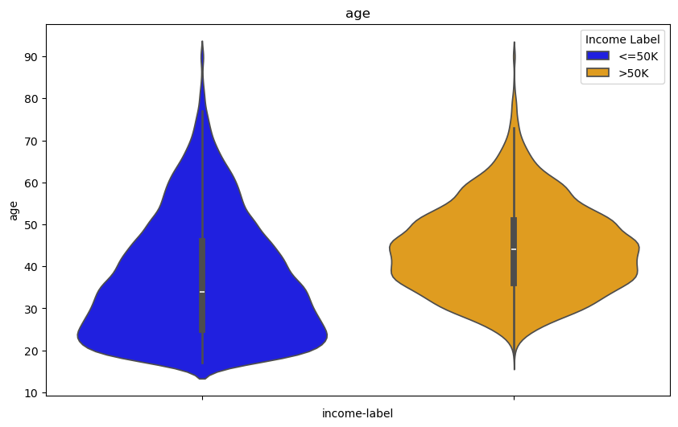

```python
crea_violin_plot(df, 'age')
```

Es pot veure que la distribució de les edats per a les persones que guanyen <=50k és més àmplia, cosa que indica una major dispersió d'edats dins aquest grup. En canvi, la distribució per a les persones que guanyen >50k és més estreta, això vol dir que la majoria de les persones dins d'aquesta categoria està concentrada en un rang d'edat més petit.

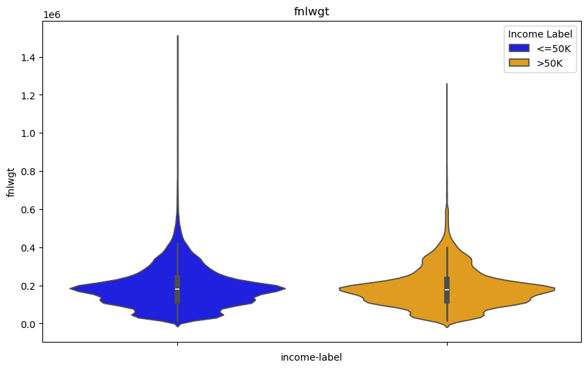

```python
crea_violin_plot(df, 'fnlwgt')
```

Podem observar que tant la distribució de persones amb ingressos <=50k com la de >50k tenen una amplada considerable a la part inferior, la qual cosa implica que hi ha una gran quantitat de dades prop de valors baixos de "fnlwgt".

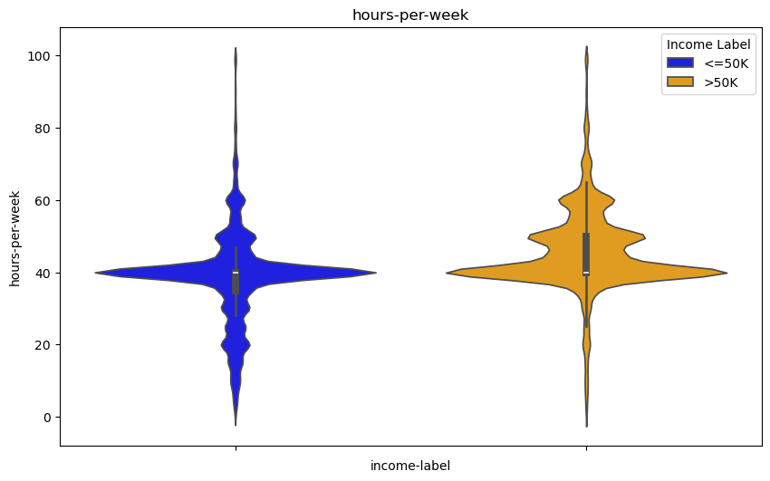

```python
crea_violin_plot(df, 'hours-per-week')
```

Observem que la distribució per aquelles persones que guanyen >50k és més alta respecte al nombre d'hores treballadas que respecte als que guanyen <=50k.

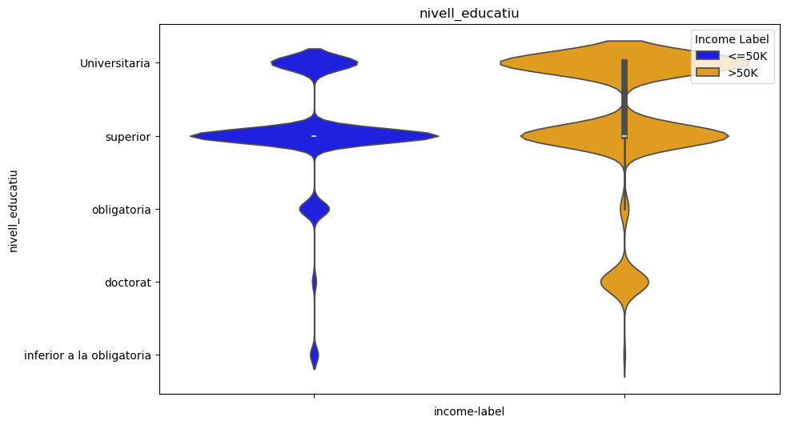

```python
crea_violin_plot(df, 'nivell_educatiu', grups_nivell_educatiu)
```

Podem veure que la majoria de la gent que guanya <=50k té estudis superiors. En canvi, les persones que guanyen >50k acostumen a tindre carrera universitaria.

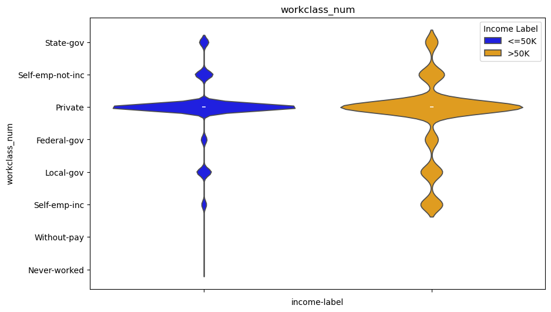

```python
crea_violin_plot(df, 'workclass_num', grups_workclass)
```

Així com en les dues gràfiques observem que la majoria de persones es dediquen a l'empresa privada, les persones que cobren >50k estan més disperses que les que estan per sota.

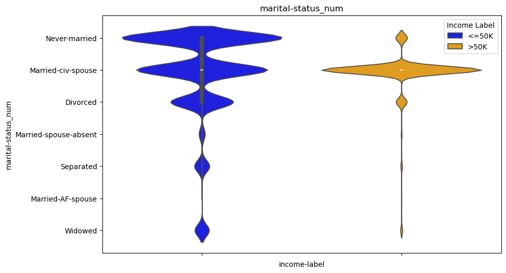

```python
crea_violin_plot(df, 'marital-status_num', grups_marital_status)
```

Per a la categoria d'ingressos <=50k, veiem que hi ha una major densitat en l'estatus de "Never-married" (mai casats), amb un violí relativament ampli, que s'afina a mesura que es desplaça cap a l'estat de "Married-civ-spouse" (casats amb cònjuge civil). Això podria implicar que una proporció major de persones mai casades es troba en aquest rang d'ingressos.

Per a la categoria d'ingressos >50k, el violí és més estret i mostra que hi ha una concentració més gran de persones casades amb cònjuge civil en aquest rang d'ingressos, amb una mediana més definida. Això pot suggerir que estar casat està correlacionat amb una major probabilitat d'ingressos més alts, encara que això només es pot confirmar amb una anàlisi més profunda.

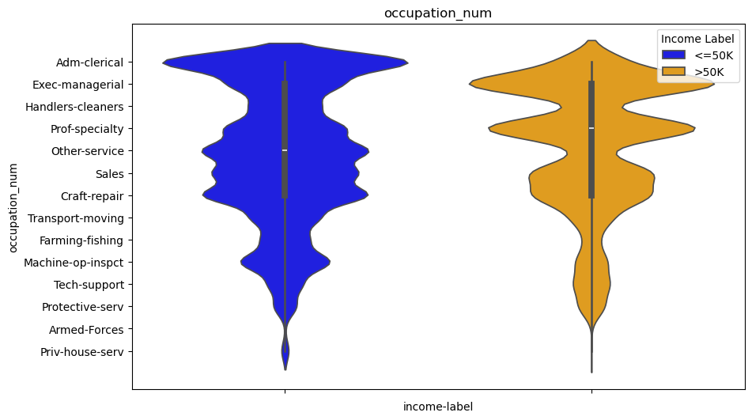

```python
crea_violin_plot(df, 'occupation_num', grups_occupation)
```

Per als ingressos <=50k, hi ha una amplada considerable en les ocupacions administratives i de serveis, lo que pot indicar que hi ha una major densitat de persones en aquestes professions dins d'aquest rang d'ingressos. També es veu una amplada notable en professions com la venda (Sales) i serveis diversos (Other-service).

Per als ingressos >50k, la distribució mostra una concentració més gran en ocupacions executives i de gestió, amb una mediana més centrada, suggerint que les persones en aquestes posicions tendeixen a tenir ingressos més alts. El violí per a aquest grup d'ingressos és menys ampli en ocupacions de servei i administratives, indicant menys densitat de persones en aquestes professions que guanyen més de 50k.

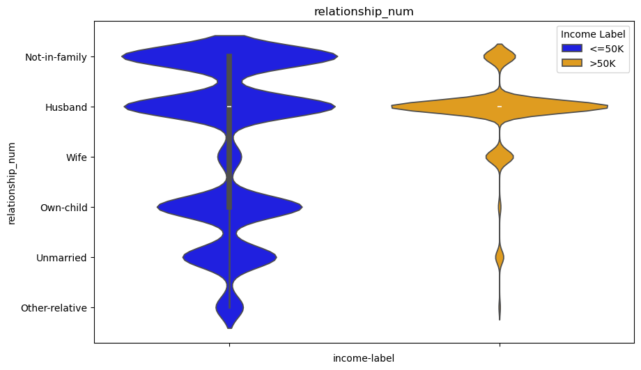

```python
crea_violin_plot(df, 'relationship_num', grups_relationship)
```

Observem que per als ingressos <=50k, hi ha una distribució més àmplia per a "Not-in-family" i "Own-child" (fill propi), suggerint que hi ha una major variabilitat dels ingressos entre aquests membres de la família. La presència d'una àmplia base en la categoria "Own-child" pot reflectir que aquest grup inclou molts individus joves o estudiants amb ingressos més baixos o sense ingressos.

Per als ingressos >50k, la distribució és més estreta i centrada, especialment en la categoria "Husband" (marit), on la mediana està més definida. Això pot indicar que els marits tenen més probabilitats de tenir ingressos més alts. Les altres categories presenten una menor densitat en aquest grup d'ingressos.

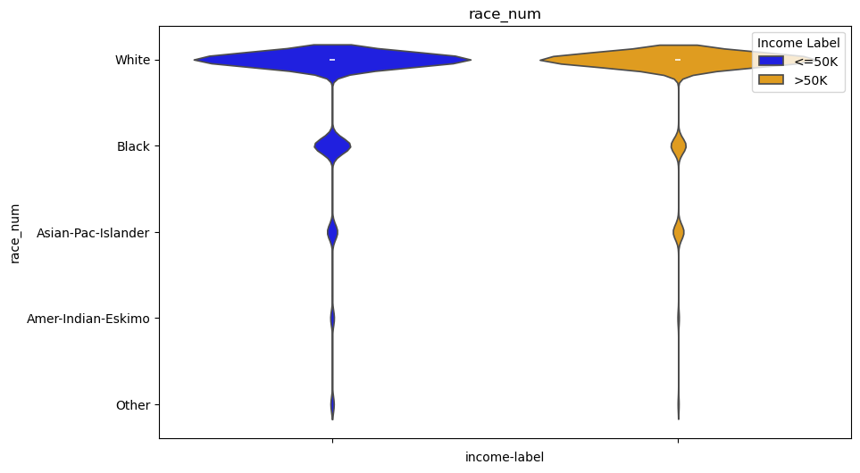

```python
crea_violin_plot(df, 'race_num', grups_race)
```

Per a la categoria d'ingressos <=50k, la distribució és més àmplia en la categoria "White" (Blanc), suggerint que hi ha una major variabilitat d'ingressos dins d'aquest grup racial. També hi ha una presència notable en la categoria "Black" (Negre), encara que amb una distribució més estreta.

Per a la categoria d'ingressos >50k, la distribució mostra una concentració d'individus d'origen "White" amb aquests nivells d'ingressos més alts, com s'indica per la seva mediana més centrada. Les categories "Asian-Pac-Islander" (Asiàtic o Illenc del Pacífic) i "Amer-Indian-Eskimo" (Nadiu Americà o Esquimal) mostren una presència més petita, amb violins més estrets.

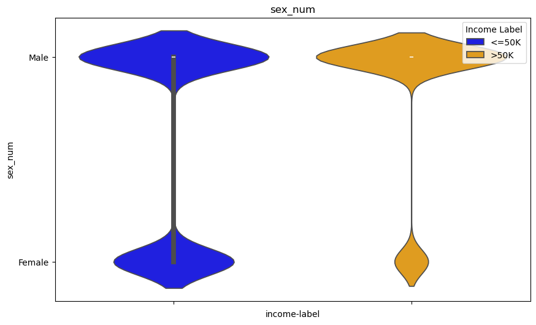

```python
crea_violin_plot(df, 'sex_num', grups_sex)
```

Observem que per als homes (Male), la distribució per als ingressos <=50k és ampla, indicant una gran variabilitat d'ingressos en aquesta categoria. En comparació, el violí per als ingressos >50k és més estret, però més ample a la part superior, suggerint que una proporció significativa d'homes guanya més de 50k.

Pel que fa a les dones (Female), la distribució per als ingressos <=50k és també relativament àmplia, però notablement més petita que la dels homes, indicant que hi ha menys variabilitat en els ingressos de les dones dins d'aquest rang. Per als ingressos >50k, la distribució és molt més estreta, amb una menor proporció de dones que guanyen més d'aquesta quantitat.

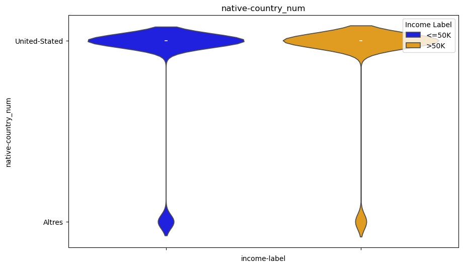

```python
crea_violin_plot(df, 'native-country_num', grups_native_country)
```

La categoria "United-Stated" mostra una distribució més àmplia per als ingressos <=50k, indicant una gran variabilitat d'ingressos entre les persones natives dels Estats Units dins d'aquest rang. Per als ingressos >50k, el violí és més estret, però amb una base ampla, suggerint que una proporció significativa de persones nadiues dels Estats Units guanya més de 50k.

Per a fer la matriu de correlació considerarem <=50k (0) i >50k (1). Per fer-ho afegirem al df una columna numèrica temporal que després borrarem.

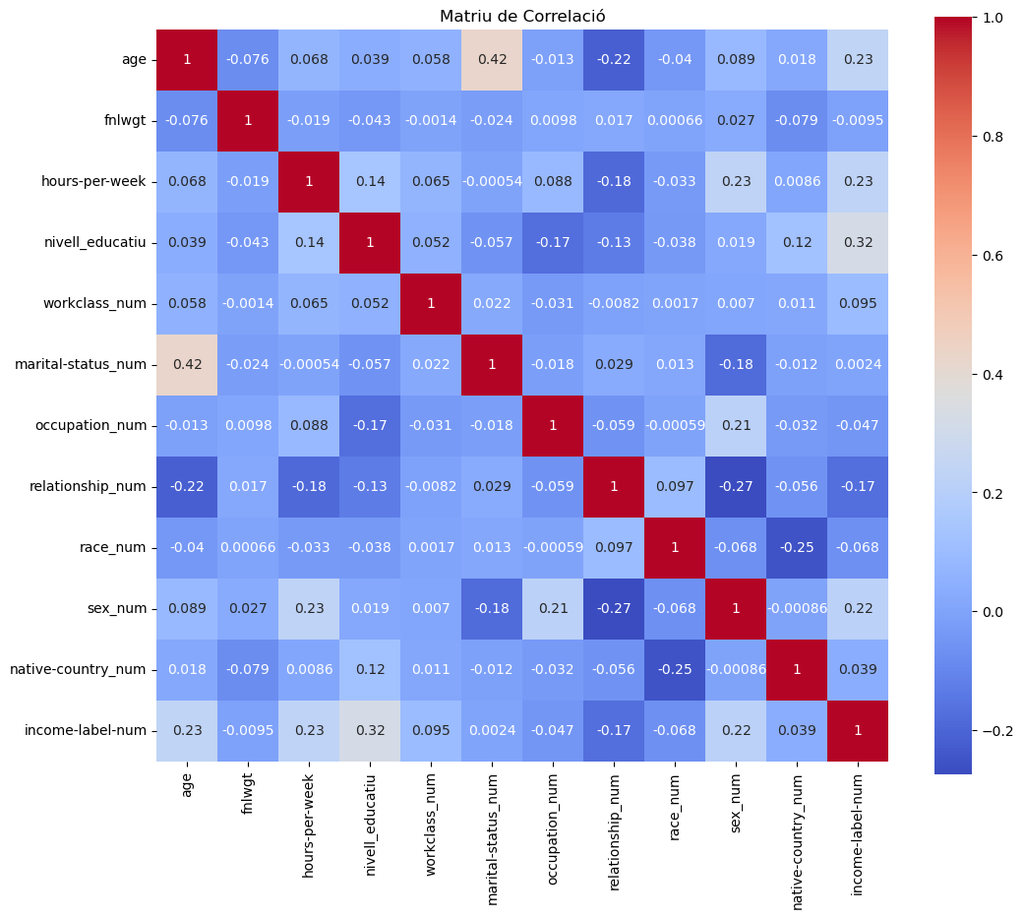

```python
# Convertim la columna 'income-label' a tipus numèric temporalment per a la correlació
df['income-label-num'] = df['income-label'].map({'<=50K': 0, '>50K': 1})


correlation_matrix = df.corr(numeric_only=True)

plt.figure(figsize=(12, 10))
sb.heatmap(correlation_matrix, annot=True, cmap='coolwarm', square=True)
plt.title('Matriu de Correlació')
plt.show()

# Tornem a convertir 'income-label-num' a la seva forma original
df.drop('income-label-num', axis=1, inplace=True)
```

Aquesta matriu de correlació ens permet buscar quines variables tenen una correlació més forma amb 'income-label', cosa que permetrà entendre quins factor estan més associats amb els ingressos més alts o més baixos.

- Edat (age): Hi ha una correlació positiva lleu amb els ingressos, indicant que l'edat pot poser un factor relacionat amb el sou.
- Hores treballades per setmana (hours-per-week): Aquesta variable també mostra una correlació positiva amb els ingressos, el que suggereix que treballar més hores pot conduir a ingressos més alts.
- Nivell educatiu (education_num): Hi ha una correlació positiva moderada amb els ingressos, suggerint que un major nivell educatiu pot estar associat amb ingressos més alts.

Abans de fer els pairplots, pensarem quines variables poden ser les més representatives:

- Nivell Educatiu: La distribució a través del nivell d'estudis pot ser informatiu. Aquesta variable ens podria mostrar, per exemple, si una educació superior es correspon amb uns ingressos més alts.
- Work Class: Pot ser interessant veure com certes classes treballadores es relacionen amb els ingressos.
- Marital Status: Aquesta variable podría tindre diferent distribucions en l'espectre dels ingressos, cosa que podria mostrar certs patrons socials i econòmics.
- Occupation: Diferents ocupacions podrien mostrar una clara diferència en els ingressos.
- Relationship:
- Race: Tot i que pot ser molt interessant, al estar la mostra molt desviada cap a la població blanca, descartarem aquesta variable.
- Sex: Aquesta variable ens podria mostrar les diferències en els ingressos entre diferents sexes.
- Native-Country: Al igual que amb race, la mostra está molt desviada així que la descartarem.

```python
df_pairplots = df.drop(columns=['race_num', 'native-country_num', 'fnlwgt'])
```

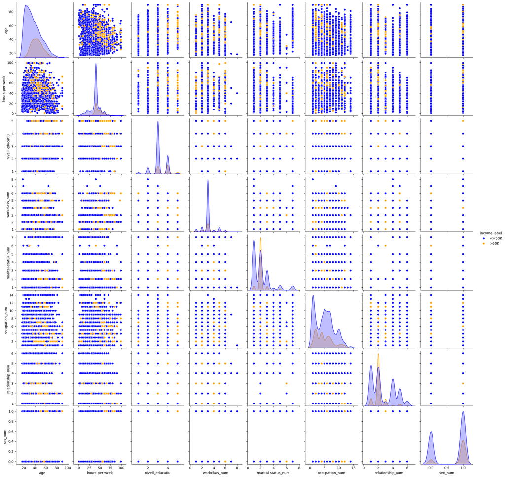

```python
# el fem només dels primers 10000 registres
sb.pairplot(df_pairplots.iloc[0:9999, :].dropna(), hue="income-label", palette=colors_plot)
plt.savefig('pairplot.png')
```

Al tindre moltes variables diferens i la majoria d'elles categòriques, és complicat poder veure patrons que a priori demostrin les relacions dels ingressos. Tot i això, es poden treure certes conclusions:

- Es pot veure que els adults que tenen entre 40 i 60 anys i tenen el màxim nivell d'estudis tenen més possibilitats de guanyar més de 50k.
- Els adults amb màxim nivell d'estudis i que superen la mitja jornada, tenen més possibilitats de guanyar més de 50k.
- Sembla que els homes que treballen més hores a la setmana tenen més possibilitats de guanyar més de 50k que les dones que treballen el mateix nombre d'hores.

## SVD

[ inici del document ]

La descomposició en valors singulars o SVD és una tècnica matemàtica que es fa servir en el processament de dades lineals. Es tracta d'una generalització de la diagonalització d'una matriu quadrada a qualsevol matriu de dimensió $mxn$. El que es fa és descomposar la matriu d'entrada en tres matrius més simples, obtenint així propietats essencials de la matriu original.

La descomposició es descriu amb la següent equació:

$A=UΣ V^{*}$ on,

- $A$ és la matriu original de dimensió $mxn$
- $Σ$ una matriu diagonal $mxn$ amb elements no negatius. Aquests elements són els valors singulars de A i ens proporcionen informació sobre la importància de cada vector singular.
- $V^{*}$ és la matriu transposada d'una matriu $nxn$ ortogonal. Les columnes de $V^{*}$ (files de $V$) son els vectors singulars de A.

Per a l'obtenció d'aquestes matrius es dur a terme el següent procés:

1. Calcular $A^{*}·A$ i $A·A^{*}$
2. Trobar els Eigenvalors i Eigenvectors
   - Eigenvalors i Eigenvectors de $A^{*}·A$: Els Eigenvectors son les columnes de $V$ i els seus Eigenvalors son els quadrats dels valors singulars de $A$.
   - Eigenvalors i Eigenvectors de $A·A^{*}$: Els Eigenvectors son les columnes de $U$.
3. Ordenar els valors singulars: Els Eigenvalors obtinguts són ordenats de major a menor i, un cop feta l'arrel quadrada, són els valors singulars de $A$ i formen la matriu diagonal $Σ$
4. Formar la matriu $Σ$: Aquesta és una matriu diagonal de dimensió $mxn$ que conté els valors singulars en la seva diagonal, ordenats de major a menor. Els valors fora de la diagonal son 0.
5. Contruïr les matrius $U$ i $V$:
   - Matriu $U$: Els Eigenvector de $A·A^{*}$, ordenats en funció dels valors singulars, formen la matriu $U$.
   - Matriu $V$: Els Eigenvector de $A^{*}·A$, ordenats en funció dels valors singulars, formen la matriu $V$.
6. Comprovacions: Finalment es verifica que $A=UΣV*$

En python hi ha llibreria com **scipy** que ja tenen implementada la aplicació de SVD a un dataframe, a continuació en mostrem el procés. Per seguir l'explicació anomenarem A a la matriu que conté el nostre dataframe, a més a més, eliminarem la columna 'income-label', ja que és la variable objectiu del nostre estudi.

```python
df_SVD = df.copy()
df_SVD.drop(columns='income-label', inplace=True)
A=df_SVD
```

Fem servir la funció **svd** de **SciPy** oer desccomposar la matriu. En aquest cas $U$ i $Vt$ son matrius ortogonals i $s$ és un vector de valors singulars

```python
U, s, Vt = svd(A)
```

```python
print(f'La matriu U és: \n {U} \n')
print(f'La matriu Vt és: \n {Vt} \n')
print(f'La matriu s és: \n {s} \n')
```

```
La matriu U és:
 [[-1.97895818e-03  6.84027809e-03  3.12772285e-04 ... -7.82937741e-03
  -3.02783032e-03 -6.95632225e-03]
 [-2.12690254e-03  4.71474904e-03 -1.16309102e-02 ... -4.14971501e-03
   4.51129710e-03  3.03686190e-03]
 [-5.50537141e-03  1.24169797e-03  6.02261656e-06 ...  3.07485257e-03
   2.32268034e-03  4.29521306e-03]
 ...
 [-3.87821248e-03  6.34139640e-03 -5.93387988e-03 ...  9.99362293e-01
  -2.63075228e-05 -5.09046569e-05]
 [-5.14397326e-03 -2.70329303e-03 -1.31295927e-03 ... -2.47194388e-05
   9.99740335e-01 -2.16762097e-05]
 [-7.35068150e-03  1.42345428e-04 -4.61568875e-03 ... -5.34622311e-05
  -2.35267442e-05  9.99499234e-01]]

La matriu Vt és:
 [[-1.52945459e-04 -9.99999975e-01 -1.62221753e-04 -1.30341283e-05
  -1.24963841e-05 -8.32184911e-06 -2.02847893e-05 -1.02883266e-05
  -4.91758825e-06 -2.72183347e-06 -3.62773680e-06]
 [ 7.13254277e-01 -2.24778053e-04  6.92090144e-01  4.76906850e-02
   4.48404949e-02  3.54155066e-02  7.26741005e-02  2.97663541e-02
   1.67611740e-02  1.04904042e-02  1.34774734e-02]
 [-6.97273238e-01 -1.00801382e-05  7.15520214e-01  9.89110463e-03
   5.67911786e-03 -2.85318723e-02  2.81929074e-02  8.41138800e-03
   2.53613002e-03  4.70116078e-03  1.60529102e-03]
 [ 3.64083227e-02  4.15773159e-06  7.59604944e-02 -1.74581092e-02
  -4.62951192e-02 -1.01292879e-02 -9.91348964e-01 -7.55929942e-02
  -2.77166837e-02 -2.95315374e-02 -1.50471382e-02]
 [ 3.58657378e-02  4.31553777e-06  4.00031594e-02 -2.34121949e-01
  -2.96816123e-01 -1.88207237e-01  9.51773862e-02 -8.85008445e-01
  -1.40079640e-01  5.06098896e-02 -6.55452847e-02]
 [ 2.17733517e-02 -8.95636016e-07 -2.08259653e-02  2.80611153e-01
   3.51413528e-01 -8.83124328e-01 -1.75737146e-02 -1.18962994e-02
   5.02236468e-02  1.06490117e-01  5.13480100e-02]
 [ 4.28470988e-02  1.29657781e-06  3.07694852e-02 -3.83716732e-01
  -6.85980391e-01 -4.12023828e-01  1.72076376e-02  4.42615732e-01
  -8.67713657e-02 -1.52797286e-02 -7.53563123e-02]
 [-1.04339360e-02 -5.45430481e-07 -1.52510976e-02  8.04685920e-01
  -5.57174736e-01  5.22322595e-02  8.36125459e-03 -6.78312736e-02
   1.58035710e-01  2.48312827e-02  9.32970650e-02]
 [-4.36874290e-04  1.56885096e-07 -7.00404120e-04  2.00134674e-01
   2.96255558e-02  2.83223069e-02  1.34906672e-02  7.74138253e-02
  -9.67641097e-01  1.69524433e-02  1.24394643e-01]
 [ 6.48528279e-03  2.90566205e-07  7.45330477e-03  5.48469275e-02
   2.32025716e-02 -9.54234690e-02  3.39304453e-02 -4.98868099e-02
  -1.53161797e-02 -9.91238560e-01 -2.86665048e-02]
 [-2.31481013e-03 -5.43374753e-08 -1.63082676e-03 -1.61081469e-01
  -4.23526254e-02 -9.94454858e-03 -9.16569607e-03 -3.09205423e-02
   8.79275961e-02 -3.74553263e-02  9.80804695e-01]]

La matriu s és:
 [3.91701106e+07 5.62708339e+03 2.26343210e+03 5.79512497e+02
 3.14745640e+02 2.03767621e+02 1.89886729e+02 1.39240026e+02
 1.14411683e+02 7.65930544e+01 5.18196808e+01]
```

A cotninuació convertirem els valors singulars a una matriu diagonal

```python
Sigma = np.zeros(A.shape)
for i in range(min(A.shape[0], A.shape[1])):
    Sigma[i, i]=s[i]
print(f'La matriu Sigma és: \n {Sigma} \n')
```

```
La matriu Sigma és:
 [[3.91701106e+07 0.00000000e+00 0.00000000e+00 ... 0.00000000e+00
  0.00000000e+00 0.00000000e+00]
 [0.00000000e+00 5.62708339e+03 0.00000000e+00 ... 0.00000000e+00
  0.00000000e+00 0.00000000e+00]
 [0.00000000e+00 0.00000000e+00 2.26343210e+03 ... 0.00000000e+00
  0.00000000e+00 0.00000000e+00]
 ...
 [0.00000000e+00 0.00000000e+00 0.00000000e+00 ... 0.00000000e+00
  0.00000000e+00 0.00000000e+00]
 [0.00000000e+00 0.00000000e+00 0.00000000e+00 ... 0.00000000e+00
  0.00000000e+00 0.00000000e+00]
 [0.00000000e+00 0.00000000e+00 0.00000000e+00 ... 0.00000000e+00
  0.00000000e+00 0.00000000e+00]]
```

Fem una comprovació dels resultats mitjançant asserts

```python
# Mirem si A = U @ Sigma @ Vt
assert np.allclose(A, np.dot(U, np.dot(Sigma, Vt))),  'A és diferent al producte de les altres matrius'
print(' A = U @ Sigma @ Vt \n')

# Mirem la ortogonalitat de U i Vt
# assert np.allclose(np.dot(U.T, U), np.eye(U.shape[1])), 'U no és ortogonal' | Comentat ja que requereix molt de processament fer el càlcul
# assert np.allclose(np.dot(Vt, Vt.T), np.eye(Vt.shape[0])), 'Vt no és ortogonal' | Comentat ja que requereix molt de processament fer el càlcul
print('U i Vt són ortogonals \n')

# Mirem les dimensions
assert U.shape[0] == A.shape[0], 'El nombre de files de U no és igual a les de A'
assert Sigma.shape == A.shape, 'Les dimensions de Sigma no són iguals a les de A'
assert Vt.shape[1] == A.shape[1], 'El nombre de columnes de Vt no és igual a les de A'
print('Les dimensions quadren')
```

```
 A = U @ Sigma @ Vt

U i Vt són ortogonals

Les dimensions quadren
```

Ara farem servir les matrius obtingudes per:

1. Reduïr la dimensionalitat
2. Anàlisi de components principals
3. Interpretació de les dades

### Reduïr la dimensionalitat

Aquí hem de decidir quants components volem conservar. Per exemple, conservarem els components que representen el 90% de la variància. Es poden provar diferents valors de 'k' per a obtindre resultats diferents.

```python
#Calculem la variància per a cada valor singular
variancies = s**2/np.sum(s**2)

# Calculem la variancia acumulada
variancia_acumulada = np.cumsum(variancies)

# busquem el nombre de components pel 90% de variancia total
k = np.where(variancia_acumulada >0.9)[0][0]+1

# reduïm la dimensionalitat
U_k = U[:, :k]
Sigma_k = np.diag(s[:k])
Vt_k = Vt[:k, :]

# Aproximació obtinguda
A_k = np.dot(U_k, np.dot(Sigma_k, Vt_k))

# mostrem la matriu
print(f'La matriu amb dimensions reduïdes és: {A_k} \n')
```

```
La matriu amb dimensions reduïdes és: [[1.18557218e+01 7.75160086e+04 1.25747831e+01 ... 3.81191823e-01
  2.10985672e-01 2.81207684e-01]
 [1.27420403e+01 8.33110057e+04 1.35148577e+01 ... 4.09689233e-01
  2.26758689e-01 3.02230409e-01]
 [3.29820775e+01 2.15646002e+05 3.49824733e+01 ... 1.06045827e+00
  5.86952519e-01 7.82306955e-01]
 ...
 [2.32339465e+01 1.51910008e+05 2.46431084e+01 ... 7.47030888e-01
  4.13473754e-01 5.51089540e-01]
 [3.08169808e+01 2.01489997e+05 3.26860613e+01 ... 9.90844864e-01
  5.48422230e-01 7.30952694e-01]
 [4.40371283e+01 2.87927000e+05 4.67080239e+01 ... 1.41590647e+00
  7.83689364e-01 1.04452340e+00]]
```

Podem veure les diferències entre A i A_k de la següent manera

```python
# Calcular espai necessari per guardar A
espai_A = A.size

# Calcular espai necessari per guardar A_k
# inclou U_k (m x k), Sigma_k (k x k), i Vt_k (k x n)
espai_A_k = U_k.size + Sigma_k.size + Vt_k.size

print("Espai requerit per A:", espai_A)
print("Espai requerit per A_k:", espai_A_k)
print("Nombre de components en A_k:", k)

reduccio = ((espai_A - espai_A_k) / espai_A) * 100
print(f"Reducció de dimensionalidad: {reduccio:.2f}%")
```

```
Espai requerit per A: 357874
Espai requerit per A_k: 32546
Nombre de components en A_k: 1
Reducció de dimensionalidad: 90.91%
```

### Anàlisi de components principals

Per fer un anàlisi PCA mitjançant SVD seguirem els següents passos:

1. Determinar el nombre de components principals (k): Ja ho hem fet
2. Obtindre els components principals: Corresponen a les primeres $k$ files de la matriu $V^{*}$
3. Projectar les dades en el noy espai de components principals: Es pot fer per reduïr la dimensionalitat

```python
components_principals = Vt[:k, :]

# projecció
A_pca = np.dot(A, components_principals.T)
print('La matriu A_pca és: \n', A_pca)
```

```
La matriu A_pca és:
 [[ -77516.01060484]
 [ -83311.00781184]
 [-215646.00702185]
 ...
 [-151910.01172652]
 [-201490.00166255]
 [-287927.00735874]]
```

Cada fila de $A_{pca}$ és una observació de les dades originals projectada en l'espai de $k$ components principals. Els components principals, les files de $Vt[:k,:]$ són combinacions linials de les característiques originals.

### Interpretació de dades

1. Els valors singulars en $Σ$ indiquen l'importància relativa de cada component principal. Els valors singulars més grans són els components que representen més variància de les dades.
   - Un valor singular gran implica que el component principal és significatiu per explicar la variància de les dades
   - Estan ordenats de major a menor, així que els primers seran més importants
2. Interpretar els components principals
   - Observem els pesos per entendre quines característiques aporten més informació
   - Patrons i relacions: Pot ser que es mostrin patrons i/o relacions de les dades. Per exemple, un component principal que té pesos alts en certes característiques indica que aquestes varien juntes de forma significativa

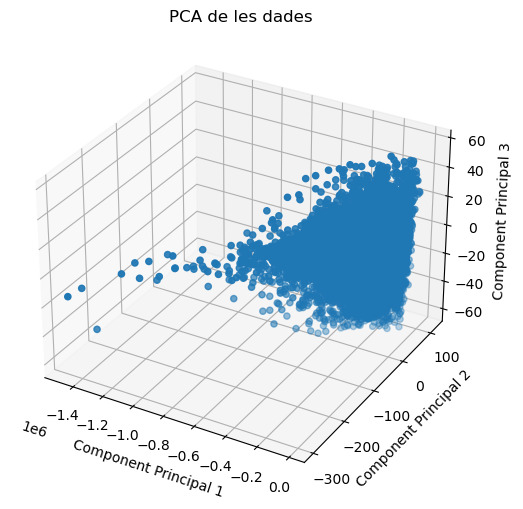

```python
k = 3
components_principals = Vt[:k, :]

# projecció
A_pca = np.dot(A, components_principals.T)

if A_pca.shape[1] in [2, 3]:
    plt.figure(figsize=(8, 6))
    if A_pca.shape[1] == 3:
        ax = plt.axes(projection='3d')
        ax.scatter(A_pca[:, 0], A_pca[:, 1], A_pca[:, 2])
    else:
        plt.scatter(A_pca[:, 0], A_pca[:, 1])
    plt.title("PCA de les dades")
    plt.xlabel("Component Principal 1")
    plt.ylabel("Component Principal 2")
    if A_pca.shape[1] == 3:
        ax.set_zlabel("Component Principal 3")
    plt.show()
```

En la figura podem veure una visualització 3D del anàlisi PCA

- eixos: Els components són combinacions lineals de les variables originals del dataset, estan ordenats per la quantitat de variància que cada un captura
- Distribució de les dades: Són projeccions de les observacions de les dades

Es pot veure una agrupació de punts a la part dreta, això pot indicar un grup que té característiques comunes. En vanci, a l'esquerra es veuen outliners

## Conclusions

[ inici del document ]

Durant la pràctica hem partit d'un conjunt de dades de més de 32000 registres dels cuals, mitjançant mètodes de ciència de dades, hem pogut obtindre informació valuosa per a la propera pràctica en la que implementarem un model de classificació.

Donant un punt de vista més personal, aquesta pràctica m'ha agradat especialment ja que a mesura que la he anat fent he après coses que he pogut aplicar a la meva feina, estic com a research assitant a la UAB, al departament de Sistemes de telecomunicació. Actualment estic treballant amb un dataset molt gran de pacients i he fet un anàlisi semblant al de aquesta pràctica, cosa que m'ha ajudat a tractar majoritariament missing values.